# Importance sampling in VAR models

24 de maio de 2017

## Contents

1. Bayesian VAR with Stochastic volatility
2. Importance sampling
3. Importance sampling application in (Uhlig 1997)
4. Next steps

## Uhlig (1997) - General model

The \(Var(k)\)-model with time-varying error precision matrices is given by the measurement equation

\[ \begin{eqnarray}\tag{01} Y_t &= \beta_{(0)} C_t + \beta_{(1)} Y_{t-1} + \ldots + \beta_{(k)} Y_{t-k} + \mathscr{U}(H_t^{-1})' \epsilon_t \end{eqnarray} \]

\[ \begin{eqnarray} \text{ or } &Y_t = B X_t + \mathscr{U}(H_t^{-1})'\epsilon_t \end{eqnarray} \]

\[ \begin{eqnarray} \text{with}& \ \epsilon_t \sim \mathcal{N}(0,I_m) \end{eqnarray} \]

- and the state equation
- \[ \begin{eqnarray}\tag{02} H_{t+1} = \mathscr{U}(H_t)'\Theta_t\mathscr{U}(H_t) \lambda^{-1} \end{eqnarray} \]
- \[ \begin{eqnarray} \text{with }\Theta_t \sim \mathcal{B}_m\left(\frac{\nu + c + km}{2}, \frac{1}{2} \right) \end{eqnarray} \]

## Uhlig (1997) - General model (cont.)

Assuming \(\lambda\) and \(\nu\) known, we have:

\[ \tag{03} \pi_0 (B, H_1) \propto g_0(B) \ \mathcal{NW}(B, H_1| \bar{B}_0, \lambda N_0, S_0, \nu) \]

- Which leads to
- \[ \tag{04} \pi_T(B, H_{T+1}) \propto g_T(B) \ \mathcal{NW}(B, H_{T+1}| \bar{B}_T, \lambda N_T, S_T, \nu) \]
- Where
  - \(e_t = Y_t - \bar{B}_{t-1}X_t\)
  - \(N_t = \lambda N_{t-1} + X_t X_t'\)
  - \(\bar{B}_t = (\lambda \bar{B}_{t-1}N_{t-1} + Y_t X'_t)N_t^{-1}\)
  - \(S_t = \lambda S_{t-1} + \frac{\lambda}{\nu}e_t(1-X'_tN_t^{-1}X_t)e'_t\)
  - \(g_t(B) = g_{t-1}(B)\left|(B-\bar{B}_t)N_t(B-\bar{B}_t)' + \frac{\nu}{\lambda}S_t \right|^{-\frac{1}{2}}\)

## Uhlig (1997) - The prior

- Prior selection: variant of the Minnesota Prior
  - \(\bar{B}_0\) - random walk specification;
  - \(\nu = 20\) (quaterly data) or \(\nu = 60\) (monthly data)
  - \(\lambda = \frac{\nu}{\nu+1}\)
  - \(g_0(B) = 1\)

## Uhlig - The marginal posterior \(p(B)\)

- If we integrate (04) over \(H_{T+1}\), we find
- \[ \begin{eqnarray} log(p(B)) =& \chi + \frac{1}{2} \sum_{i=1}^T \log \left|(B - \bar{B}_t)N_t(B-\bar{B}_t)' + (\nu+1)S_t \right|\\ & -\frac{l+\nu}{2} \log\left|(B - \bar{B}_T)N_T(B-\bar{B}_T)' + (\nu+1)S_T \right| \end{eqnarray} \]
  - Since it is not a known p.d.f., we need other techniques to sample from it

## Importance sampling (example)

[Example](https://htmlpreview.github.io/?https://github.com/aishameriane/msc-economics/blob/master/Bayesian-macro/article/self-study/importance-sampling.html) from (Robert and Casella 2010)

We want, for \(X \sim \mathcal{C}(0,1)\), estimate \(\mathbb{P}(X \geq 2)\):

\[ \tag{I-1} p = \mathbb{P}(X \geq 2) = \int\limits_2^\infty \frac{1}{\pi(1+x^2)}dx \]

Imagine that it is not possible to sample from (I-1) and [numerical methods](https://htmlpreview.github.io/?https://github.com/aishameriane/msc-economics/blob/master/Bayesian-macro/lecture_notes/int_num_exemplos.html) are needed.

## Importance sampling

#### Method 1

- \[ p \approx \hat{p}_1 = \frac{1}{m}\sum\limits_{j=1}^m \mathbb{I}_{X_j > 2} \]
- The variance of \(\hat{p}_1\) can be calculated using \(\frac{p(1-p)}{m}\): \(Var[\hat{p}_1] =\) 0.128 \(/m\).

#### Method 2

- The \(\mathcal{C}(0,1)\) distribution is symmetric around \(0\). Then, another estimative of \(\mathbb{P}(X \geq 2)\) is:
  - \[ p \approx \hat{p}_2 = \frac{1}{2m}\sum\limits_{j=1}^m \mathbb{I}_{|X_j| > 2} \]
- With variance equal to \(\frac{p(1-2p)}{2m} =\) 0.052 \(/m\).

## Importance sampling

#### Method 3

- There is a major drawback using methods #1 and #2
  - We want to sample from \([2, +\infty)\) but both strategies make draws in larger regions!
- Using \(X \sim \mathcal{U}(0,2)\) it is possible to rewrite \(p\):
  - \[ \tag{I-2} \begin{eqnarray} p =& \frac{1}{2} - \int\limits_0^2 \overbrace{\frac{2}{\pi(1+x^2)}}^{h(x)}\overbrace{\frac{1}{2}}^{\text{pdf of }X}dx = \frac{1}{2} - \int\limits_0^2 h(x) f_X(x) dx \\ =& 1/2 - \mathbb{E}[h(X)] \end{eqnarray} \]
- Based on (I-2), a new estimator can be proposed:
  - \[ \hat{p}_3 = \frac{1}{2} - \frac{1}{m} \sum\limits_{j=1}^m h(U_j) = \frac{1}{2} - \frac{1}{m} \sum\limits_{j=1}^m \frac{2}{\pi}(1+U_j^2) \]
- \(Var(\hat{p}_3) = \frac{1}{m} \left[\mathbb{E}(h^2(U))- \mathbb{E}(h(U))\right] = \ \) 0.0285 \(/m\).

## Importance sampling

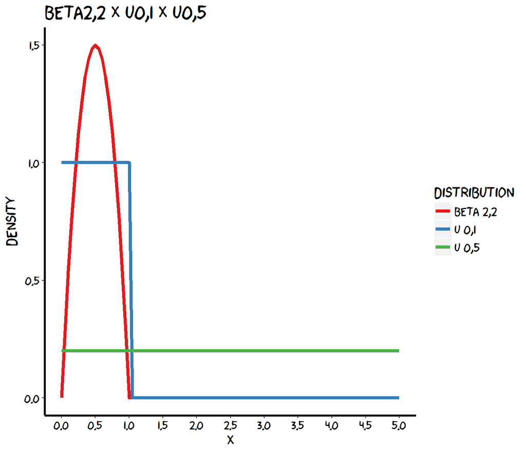

## Importance sampling

Formally, we want to obtain an estimate for:

\[ \tag{I4} I=\int\limits_\Theta g(x)p(\theta|y)d\theta = \int\limits_\Theta \frac{g(x)p(\theta|y)}{m(\theta)}m(\theta) d\theta = \mathbb{E}_m\left[\frac{g(x)p(\theta|y)}{m(\theta)} \right] \]

## IS application in (Uhlig 1997)

- The generated sample from \(I(B)\) can be used in the conditional density for \(H_{T+1}\)
  - \(H_{T+1}|B \sim \mathcal{W}_m(l+\nu,\Sigma)\)
  - \(\Sigma^{-1} = \lambda(B-\bar{B}_T)N_T(B-\bar{B}_T) + \nu S_T\)
- And it is possible now to approximate (*under certain circunstances*) \(\bar{\phi}=\mathbb{E}_{\pi_T}\left[\phi(B, H_{T+1}) \right]\) using:
  - \[ \bar{\phi}_n = \frac{\sum_{i=1}^n \phi(B_i, H_{T+1,i})w(B_i)}{\sum_{i=1}^n w(B_i)} \]

## Next steps

- Get data
- Implement (Uhlig 1997) algorithm
- Write

[figure not shown]

## References

Robert, Christian P., and George Casella. 2010. *Monte Carlo Statistical Methods*. Springer.

Uhlig, Harald. 1997. “Bayesian Vector Autoregressions with Stochastic Volatility.” *Econometrica* 65 (1): 59. doi:10.2307/2171813.